**Data 605 - Final Project**

**Hazal Gunduz**

**Problem 1.**

**Probability Density 1: X~Gamma.** Using R, generate a random variable X that has 10,000 random Gamma pdf values. A Gamma pdf is completely describe by n (a size parameter) and lambda (λ, a shape parameter). Choose any n greater 3 and an expected value (λ) between 2 and 10 (you choose).

```r
set.seed(0)

n <- 4
lambda <- 2
a <- 10000

X <- rgamma(a, n, lambda)
summary(X)
```

```
##    Min. 1st Qu.  Median    Mean 3rd Qu.    Max.
## 0.07235 1.26099 1.83317 1.99745 2.56044 7.60100
```

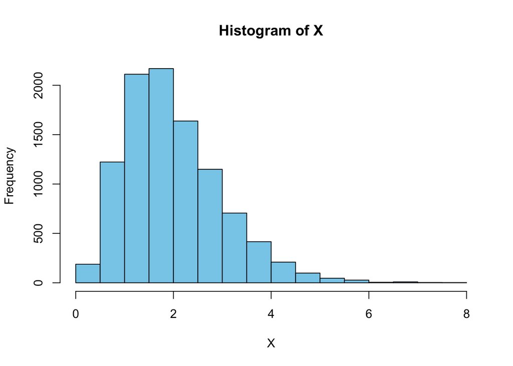

```r
hist(X, col = 'skyblue')
```

**Probability Density 2: Y~Sum of Exponentials.** Then generate 10,000 observations from the sum of n exponential pdfs with rate/shape parameter ( λ). The n and λ must be the same as in the previous case. (e.g., mysum=rexp(10000, λ) + rexp(10000, λ) + …)

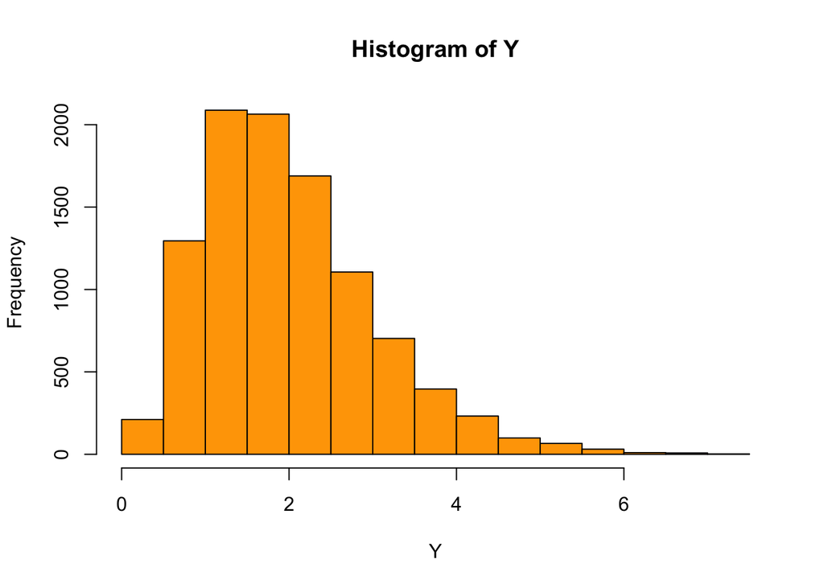

```r
set.seed(0)

Y <- rexp(a, lambda) + rexp(a, lambda) + rexp(a, lambda) + rexp(a, lambda)
hist(Y, col = 'orange')
```

**Probability Density 3: Z~Exponential.** Then generate 10,000 observations from a single exponential pdf with rate/shape parameter (λ).

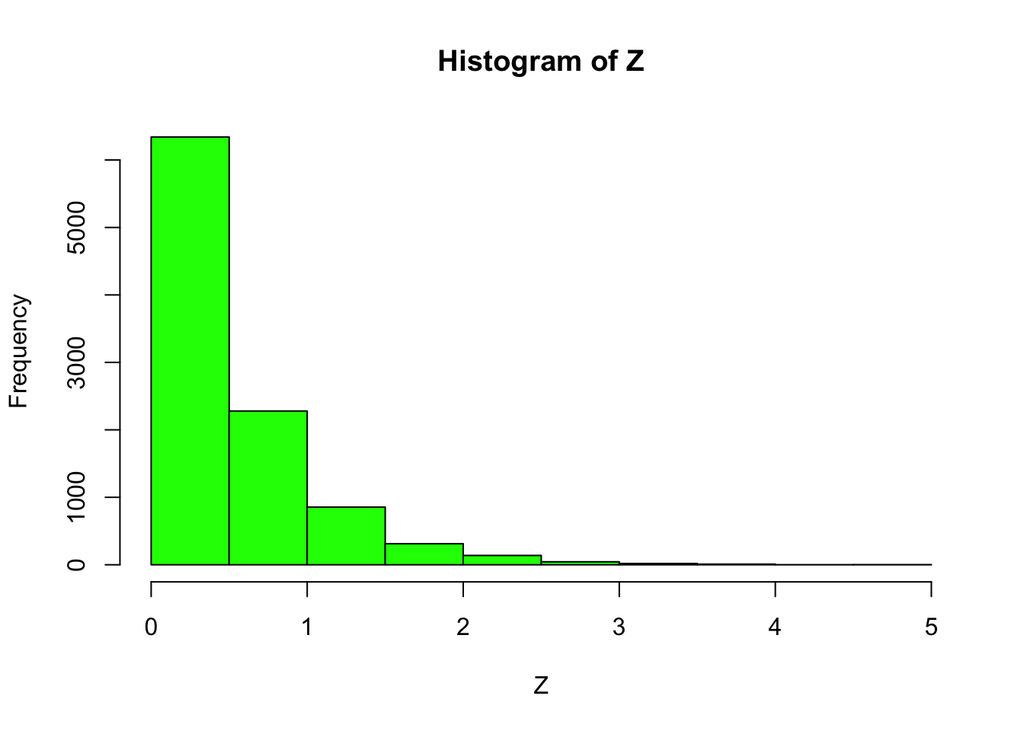

```r
set.seed(0)

Z <- rexp(a, lambda)
hist(Z, col = 'green')
```

**1a. Calculate the empirical expected value (means) and variances of all three pdfs.**

```r
n <- 4
lambda <- 2

meanX <- 4 / 2
meanX
```

```
## [1] 2
```

```r
varX <- 4 / 2^2
varX
```

```
## [1] 1
```

```r
meanY <- 4 / 2
meanY
```

```
## [1] 2
```

```r
varY <- 4 / 2^2
varY
```

```
## [1] 1
```

```r
meanZ <- (1 / 2) / 2
meanZ
```

```
## [1] 0.25
```

```r
varZ <- (1 / 2^2) / 2^2
varZ
```

```
## [1] 0.0625
```

**1b.** Using calculus, calculate the expected value and variance of the Gamma pdf (X). Using the moment generating function for exponentials, calculate the expected value of the single exponential (Z) and the sum of exponentials (Y)

λ = 2

$λe^{-xλ}$ = exponentials distribution

M(t) = $\int_{0}^{\infty} λe^{-xλ}. e^{tx} = \frac{-λ}{t - λ}$

$\frac{λ}{(t - λ)^2} = M'(t)$

$\frac{1}{λ} = M'(0)$

$\frac{2λ}{(- λ)^3}$

$\frac{2}{(λ)^2}$

**1c-e.Probability.** For pdf Z (the exponential), calculate empirically probabilities a through c. Then evaluate through calculus whether the memoryless property holds.

a.P(Z>λ | Z>λ/2) b.P(Z>2λ | Z>λ) c. P(Z>3λ | Z>λ)

```r
a <- mean(Z > lambda & Z > lambda / 2) / (mean(Z > lambda / 2))
a
```

```
## [1] 0.1543478
```

```r
b <- mean(Z > 2 * lambda & Z > lambda) / (mean(Z > lambda ))
b
```

```
## [1] 0.01408451
```

```r
c <- mean(Z > 3 * lambda & Z > lambda) / (mean(Z > lambda ))
c
```

```
## [1] 0
```

Loosely investigate whether P(YZ) = P(Y) P(Z) by building a table with quartiles and evaluating the marginal and joint probabilities.

```r
quantY <- quantile(Y, probs = c(.25,.5,.75,1))
quantY <- as.matrix(t(quantY))
colnames(quantY) = c("25% Y", "50% Y", "75% Y", "100% Y")

quantZ = quantile(Z, probs = c(.25,.5,.75,1))
quantZ = as.matrix(quantZ)
rownames(quantZ) = c("25% Z", "50% Z", "75% Z", "100% Z")

P_YZ <- quantZ %*% quantY

P_Sum <- sum(P_YZ)
```

```r
prob_YZ <- matrix(nrow = 4, ncol = 4)
for (row in 1:4) {
    for (col in 1:4) {
        prob_YZ[row,col] = P_YZ[row,col]/P_Sum
    }
}
colnames(prob_YZ) = c("25% Y", "50% Y", "75% Y", "100% Y")
rownames(prob_YZ) = c("25% Z", "50% Z", "75% Z", "100% Z")
prob_YZ
```

```
##              25% Y       50% Y       75% Y     100% Y
## 25% Z  0.002357123 0.003480398 0.004869254 0.01399171
## 50% Z  0.005767742 0.008516330 0.011914779 0.03423690
## 75% Z  0.011407022 0.016842981 0.023564187 0.06771126
## 100% Z 0.075904041 0.112075726 0.156799645 0.45056090
```

```r
RSum <- rowSums(prob_YZ)
CSum <- colSums(prob_YZ)

Result <- cbind(prob_YZ, RSum)
Result <- rbind(Result, CSum)
Result[4,4]
```

```
## [1] 0.4505609
```

```r
Result
```

```
##              25% Y       50% Y       75% Y     100% Y       RSum
## 25% Z  0.002357123 0.003480398 0.004869254 0.01399171 0.02469849
## 50% Z  0.005767742 0.008516330 0.011914779 0.03423690 0.06043575
## 75% Z  0.011407022 0.016842981 0.023564187 0.06771126 0.11952545
## 100% Z 0.075904041 0.112075726 0.156799645 0.45056090 0.79534032
## CSum   0.095435928 0.140915434 0.197147864 0.56650077 0.09543593
```

Check to see if independence holds by using Fisher’s Exact Test and the Chi Square Test. What is the difference between the two? Which is most appropriate?

```r
FisherTest <- prob_YZ * 10000

fisher.test(FisherTest, simulate.p.value = T)
```

```
##
##  Fisher's Exact Test for Count Data with simulated p-value (based on
##  2000 replicates)
##
## data:  FisherTest
## p-value = 1
## alternative hypothesis: two.sided
```

```r
chisq.test(FisherTest)
```

```
##
##  Pearson's Chi-squared test
##
## data:  FisherTest
## X-squared = 4.0282e-29, df = 9, p-value = 1
```

The Fisher Exact Test and the Chi-Square Test give the same p-value of 1 and verify that the “Y” and “Z” samples are independent.

**Problem 2.**

You are to register for Kaggle.com (free) and compete in the House Prices: Advanced Regression Techniques competition. https://www.kaggle.com/c/house-prices-advanced-regression-techniques

**Descriptive and Inferential Statistics.** Provide univariate descriptive statistics and appropriate plots for the training data set.Provide a scatterplot matrix for at least two of the independent variables and the dependent variable. Derive a correlation matrix for any three quantitative variables in the dataset. Test the hypotheses that the correlations between each pairwise set of variables is 0 and provide an 80% confidence interval. Discuss the meaning of your analysis. Would you be worried about familywise error? Why or why not?

```r
train <- read.csv(file = "~/Downloads/train.csv", header=TRUE)
head(train, 10)
```

```
##    Id MSSubClass MSZoning LotFrontage LotArea Street Alley LotShape LandContour
## 1   1         60       RL          65    8450   Pave  <NA>      Reg         Lvl
## 2   2         20       RL          80    9600   Pave  <NA>      Reg         Lvl
## 3   3         60       RL          68   11250   Pave  <NA>      IR1         Lvl
## 4   4         70       RL          60    9550   Pave  <NA>      IR1         Lvl
## 5   5         60       RL          84   14260   Pave  <NA>      IR1         Lvl
## 6   6         50       RL          85   14115   Pave  <NA>      IR1         Lvl
## 7   7         20       RL          75   10084   Pave  <NA>      Reg         Lvl
## 8   8         60       RL          NA   10382   Pave  <NA>      IR1         Lvl
## 9   9         50       RM          51    6120   Pave  <NA>      Reg         Lvl
## 10 10        190       RL          50    7420   Pave  <NA>      Reg         Lvl
##    Utilities LotConfig LandSlope Neighborhood Condition1 Condition2 BldgType
## 1     AllPub    Inside       Gtl      CollgCr       Norm       Norm     1Fam
## 2     AllPub       FR2       Gtl      Veenker      Feedr       Norm     1Fam
## 3     AllPub    Inside       Gtl      CollgCr       Norm       Norm     1Fam
```

[output cut: 117 more lines]

```r
test <- read.csv(file = "~/Downloads/test.csv")
head(test, 10)
```

```
##      Id MSSubClass MSZoning LotFrontage LotArea Street Alley LotShape
## 1  1461         20       RH          80   11622   Pave  <NA>      Reg
## 2  1462         20       RL          81   14267   Pave  <NA>      IR1
## 3  1463         60       RL          74   13830   Pave  <NA>      IR1
## 4  1464         60       RL          78    9978   Pave  <NA>      IR1
## 5  1465        120       RL          43    5005   Pave  <NA>      IR1
## 6  1466         60       RL          75   10000   Pave  <NA>      IR1
## 7  1467         20       RL          NA    7980   Pave  <NA>      IR1
## 8  1468         60       RL          63    8402   Pave  <NA>      IR1
## 9  1469         20       RL          85   10176   Pave  <NA>      Reg
## 10 1470         20       RL          70    8400   Pave  <NA>      Reg
##    LandContour Utilities LotConfig LandSlope Neighborhood Condition1 Condition2
## 1          Lvl    AllPub    Inside       Gtl        NAmes      Feedr       Norm
## 2          Lvl    AllPub    Corner       Gtl        NAmes       Norm       Norm
## 3          Lvl    AllPub    Inside       Gtl      Gilbert       Norm       Norm
```

[output cut: 117 more lines]

```r
summary(train)
```

```
##        Id           MSSubClass      MSZoning          LotFrontage
##  Min.   :   1.0   Min.   : 20.0   Length:1460        Min.   : 21.00
##  1st Qu.: 365.8   1st Qu.: 20.0   Class :character   1st Qu.: 59.00
##  Median : 730.5   Median : 50.0   Mode  :character   Median : 69.00
##  Mean   : 730.5   Mean   : 56.9                      Mean   : 70.05
##  3rd Qu.:1095.2   3rd Qu.: 70.0                      3rd Qu.: 80.00
##  Max.   :1460.0   Max.   :190.0                      Max.   :313.00
##                                                      NA's   :259
##     LotArea          Street             Alley             LotShape
##  Min.   :  1300   Length:1460        Length:1460        Length:1460
##  1st Qu.:  7554   Class :character   Class :character   Class :character
##  Median :  9478   Mode  :character   Mode  :character   Mode  :character
##  Mean   : 10517
##  3rd Qu.: 11602
##  Max.   :215245
##
##  LandContour         Utilities          LotConfig          LandSlope
##  Length:1460        Length:1460        Length:1460        Length:1460
##  Class :character   Class :character   Class :character   Class :character
##  Mode  :character   Mode  :character   Mode  :character   Mode  :character
##
##
##
##
##  Neighborhood        Condition1         Condition2          BldgType
##  Length:1460        Length:1460        Length:1460        Length:1460
##  Class :character   Class :character   Class :character   Class :character
##  Mode  :character   Mode  :character   Mode  :character   Mode  :character
##
##
##
##
##   HouseStyle         OverallQual      OverallCond      YearBuilt
##  Length:1460        Min.   : 1.000   Min.   :1.000   Min.   :1872
##  Class :character   1st Qu.: 5.000   1st Qu.:5.000   1st Qu.:1954
##  Mode  :character   Median : 6.000   Median :5.000   Median :1973
##                     Mean   : 6.099   Mean   :5.575   Mean   :1971
##                     3rd Qu.: 7.000   3rd Qu.:6.000   3rd Qu.:2000
##                     Max.   :10.000   Max.   :9.000   Max.   :2010
##
```

[output cut: 113 more lines]

```
##  Min.   : 1.000   Min.   :2006   Length:1460        Length:1460
##  1st Qu.: 5.000   1st Qu.:2007   Class :character   Class :character
##  Median : 6.000   Median :2008   Mode  :character   Mode  :character
##  Mean   : 6.322   Mean   :2008
##  3rd Qu.: 8.000   3rd Qu.:2009
##  Max.   :12.000   Max.   :2010
##
##    SalePrice
##  Min.   : 34900
##  1st Qu.:129975
##  Median :163000
##  Mean   :180921
##  3rd Qu.:214000
##  Max.   :755000
##
```

Univariate descriptive statistics describe a single variable in a dataset. We will use summary() to get a variety for SalePrice variable.

```r
summary(train$SalePrice)
```

```
##    Min. 1st Qu.  Median    Mean 3rd Qu.    Max.
##   34900  129975  163000  180921  214000  755000
```

```r
sd(train$SalePrice)
```

```
## [1] 79442.5
```

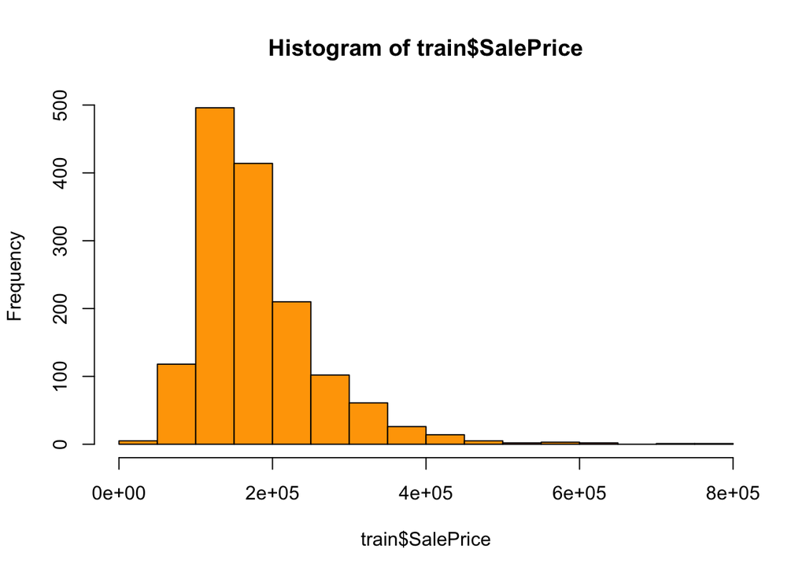

```r
hist(train$SalePrice, col = 'orange')
```

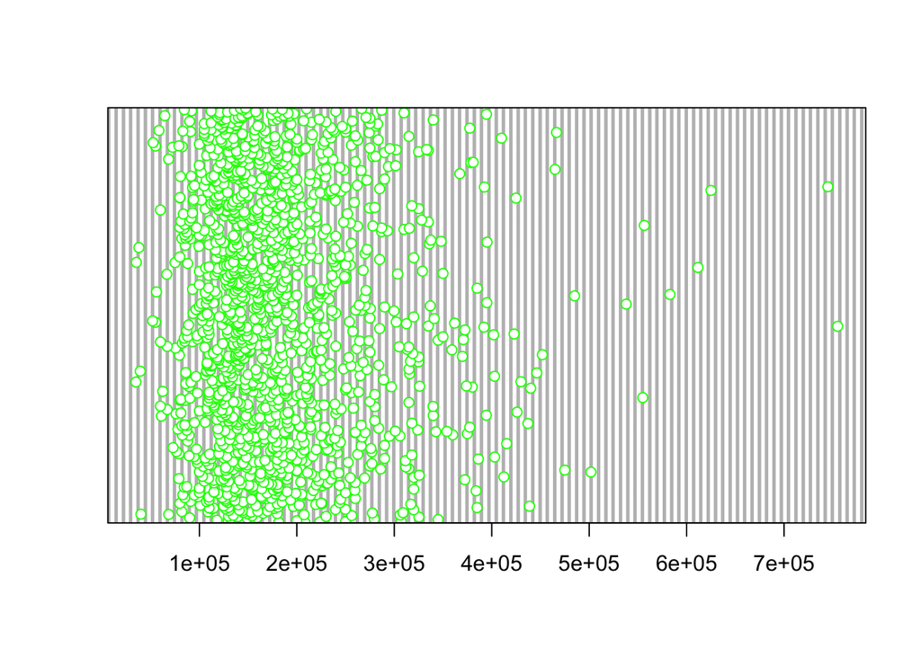

```r
dotchart(train$SalePrice, col = 'green')
```

We used a density plot to describe the SalePrice.

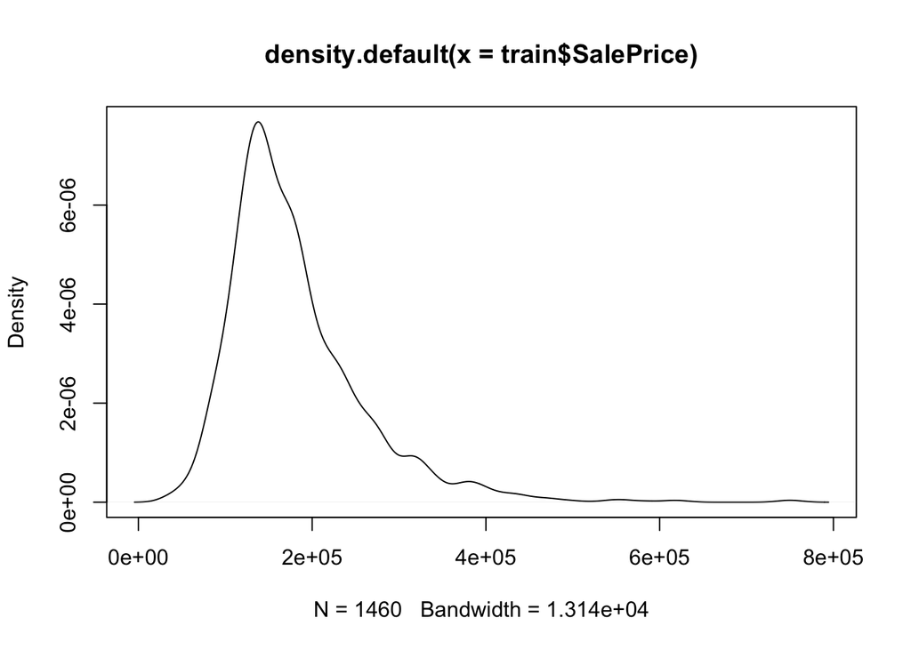

```r
plot(density(train$SalePrice))
```

The plots of log “SalePrice” charts compared to the originals in the “Histogram and DotChart” section to see if “SalePrice” is currently distributed.

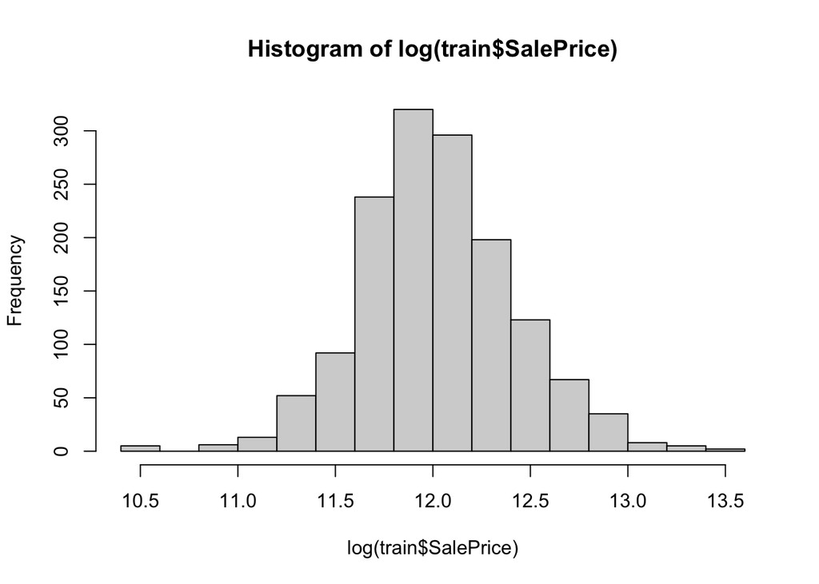

```r
hist(log(train$SalePrice))
```

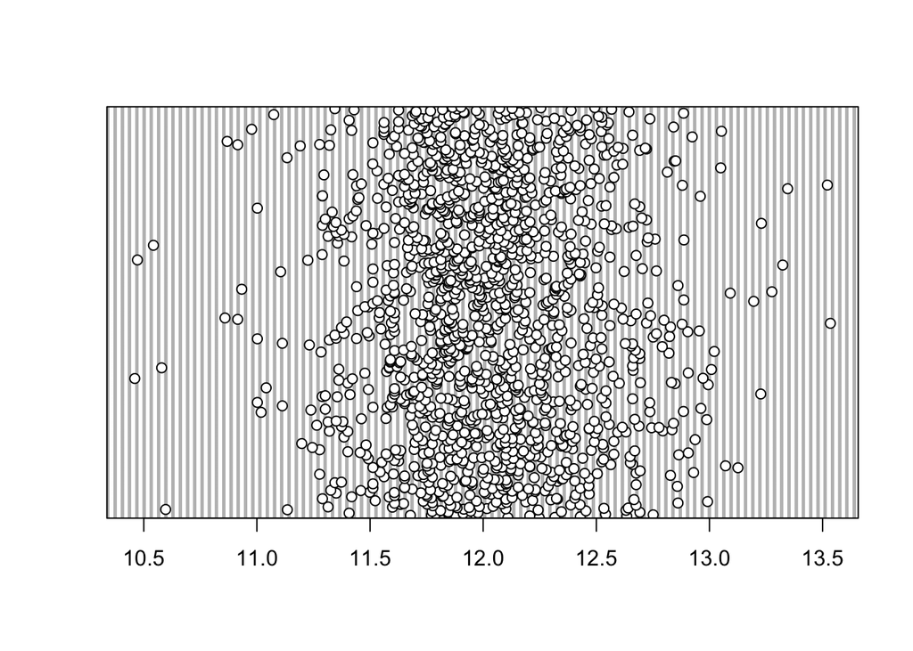

```r
dotchart(log(train$SalePrice))
```

**Linear Algebra and Correlation.** Invert your correlation matrix from above. (This is known as the precision matrix and contains variance inflation factors on the diagonal.) Multiply the correlation matrix by the precision matrix, and then multiply the precision matrix by the correlation matrix. Conduct LU decomposition on the matrix.

**Correlation**

```r
cor(train[c("SalePrice", "LotArea", "OverallQual", "OverallCond", "YearBuilt")])
```

```
##               SalePrice     LotArea OverallQual OverallCond   YearBuilt
## SalePrice    1.00000000  0.26384335  0.79098160 -0.07785589  0.52289733
## LotArea      0.26384335  1.00000000  0.10580574 -0.00563627  0.01422765
## OverallQual  0.79098160  0.10580574  1.00000000 -0.09193234  0.57232277
## OverallCond -0.07785589 -0.00563627 -0.09193234  1.00000000 -0.37598320
## YearBuilt    0.52289733  0.01422765  0.57232277 -0.37598320  1.00000000
```

```r
CorrelationMatrix <- cor(train[c("SalePrice", "OverallQual", "OverallCond")])
CorrelationMatrix
```

```
##               SalePrice OverallQual OverallCond
## SalePrice    1.00000000  0.79098160 -0.07785589
## OverallQual  0.79098160  1.00000000 -0.09193234
## OverallCond -0.07785589 -0.09193234  1.00000000
```

```r
cor.test(train$SalePrice, train$OverallQual, confidence = 0.80)
```

```
##
##  Pearson's product-moment correlation
##
## data:  train$SalePrice and train$OverallQual
## t = 49.364, df = 1458, p-value < 2.2e-16
## alternative hypothesis: true correlation is not equal to 0
## 95 percent confidence interval:
##  0.7709644 0.8094376
## sample estimates:
##       cor
## 0.7909816
```

```r
cor.test(train$SalePrice, train$OverallCond, confidence = 0.80)
```

```
##
##  Pearson's product-moment correlation
##
## data:  train$SalePrice and train$OverallCond
## t = -2.9819, df = 1458, p-value = 0.002912
## alternative hypothesis: true correlation is not equal to 0
## 95 percent confidence interval:
##  -0.12864437 -0.02666008
## sample estimates:
##         cor
## -0.07785589
```

**Precision Matrix**

We multiply the correlation matrix by the precision matrix.

```r
PrecisionMatrix <- solve(CorrelationMatrix)
PrecisionMatrix
```

```
##               SalePrice OverallQual OverallCond
## SalePrice    2.67150050 -2.11183483  0.01384614
## OverallQual -2.11183483  2.67793985  0.08177049
## OverallCond  0.01384614  0.08177049  1.00859536
```

```r
CorrelationMatrix %*% PrecisionMatrix
```

```
##                 SalePrice  OverallQual OverallCond
## SalePrice    1.000000e+00 7.112366e-17           0
## OverallQual -1.994932e-17 1.000000e+00           0
## OverallCond -1.734723e-18 2.775558e-17           1
```

LU decomposition is when you transform an nxn matrix into two triangular matrices, a (L)low triangular matrix, and a (U)pper triangular matrix. The lower triangle matrix has all the zeros above the diagonal, and the upper triangle matrix has all the zeros below the diagonal line, such as when we multiply low by upper, we get the original nxn matrix.

```r
library(pracma)
LU <- lu(PrecisionMatrix)
LU$L
```

```
##                SalePrice OverallQual OverallCond
## SalePrice    1.000000000  0.00000000           0
## OverallQual -0.790505124  1.00000000           0
## OverallCond  0.005182906  0.09193234           1
```

```r
LU$U
```

```
##             SalePrice OverallQual OverallCond
## SalePrice    2.671501   -2.111835  0.01384614
## OverallQual  0.000000    1.008524  0.09271594
## OverallCond  0.000000    0.000000  1.00000000
```

**Calculus-Based Probability & Statistics.** Many times, it makes sense to fit a closed form distribution to data. Select a variable in the Kaggle.com training dataset that is skewed to the right, shift it so that the minimum value is absolutely above zero if necessary. Then load the MASS package and run fitdistr to fit an exponential probability density function. (See https://stat.ethz.ch/R-manual/R-devel/library/MASS/html/fitdistr.html ). Find the optimal value of λ for this distribution, and then take 1000 samples from this exponential distribution using this value (e.g., rexp(1000, λ)). Plot a histogram and compare it with a histogram of your original variable. Using the exponential pdf, find the 5th and 95th percentiles using the cumulative distribution function (CDF). Also generate a 95% confidence interval from the empirical data, assuming normality. Finally, provide the empirical 5th percentile and 95th percentile of the data. Discuss.

```r
library(moments)

skewness(train$SalePrice)
```

```
## [1] 1.880941
```

```r
skewness(train$OverallQual)
```

```
## [1] 0.216721
```

```r
skewness(train$OverallCond)
```

```
## [1] 0.6923552
```

```r
skewness(train$LotArea)
```

```
## [1] 12.19514
```

```r
skewness(train$YearBuilt)
```

```
## [1] -0.6128307
```

```r
range(train$SalePrice)
```

```
## [1]  34900 755000
```

The lowest Sale Price is $34,900.

```r
library(MASS)

ExpProbability <- fitdistr(train$SalePrice, "exponential")
ExpProbability
```

```
##        rate
##   5.527268e-06
##  (1.446552e-07)
```

```r
lambda <- ExpProbability$estimate
set.seed(1000)
GenerationData <- rexp(1000, rate = lambda)
lambda
```

```
##         rate
## 5.527268e-06
```

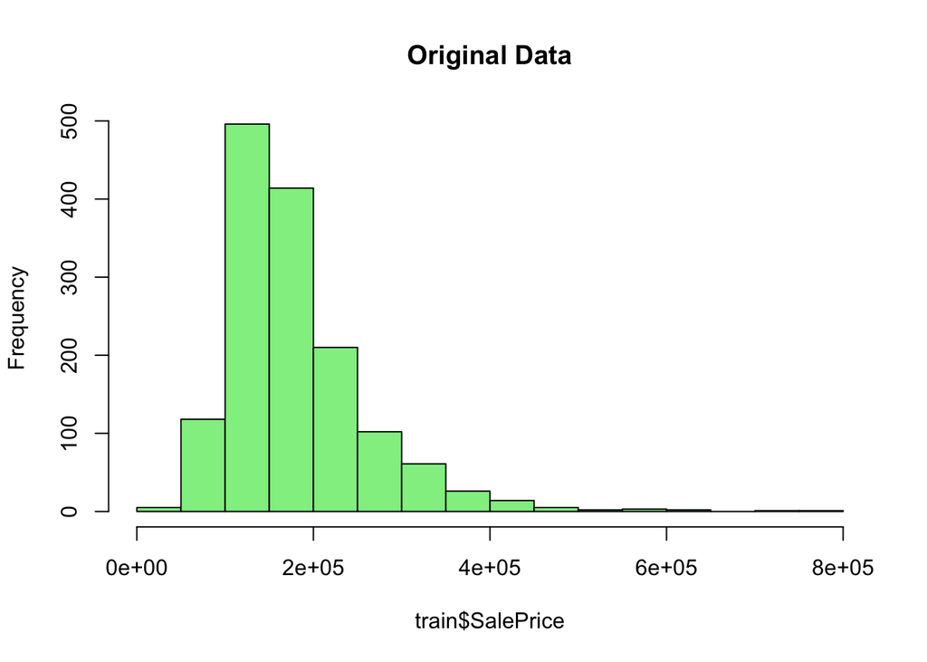

```r
hist(train$SalePrice, main = "Original Data", col = "lightgreen")
```

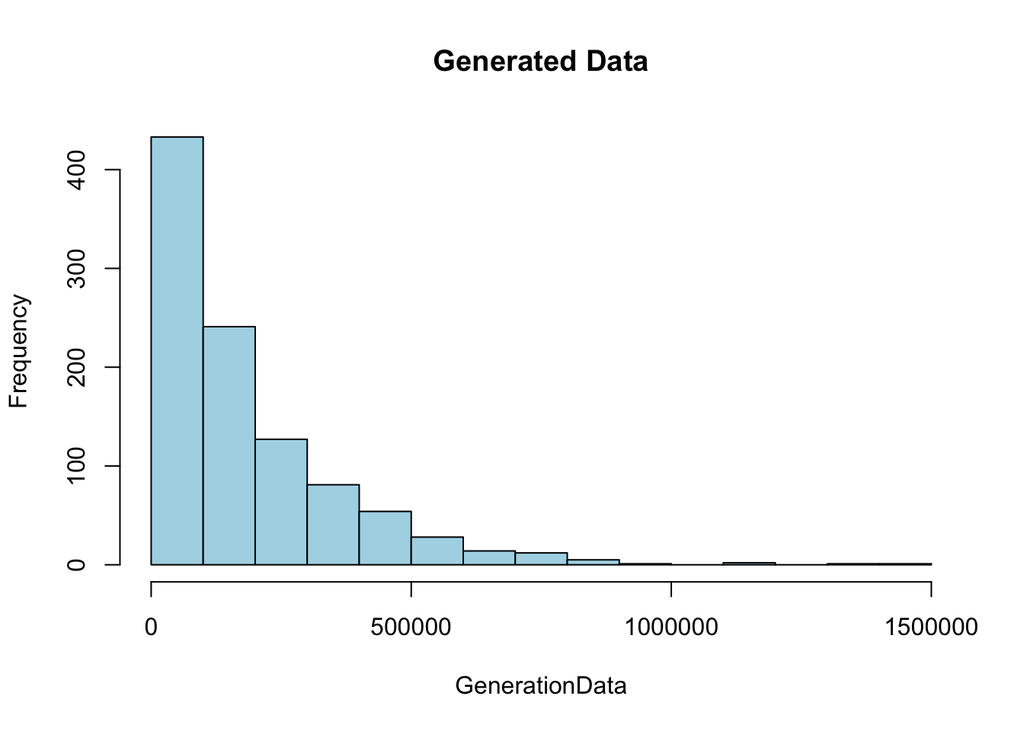

```r
hist(GenerationData, main = "Generated Data", col = "lightblue")
```

**5th and 95th Percentiles**

```r
qexp(0.05, rate = lambda)
```

```
## [1] 9280.044
```

```r
qexp(0.95, rate = lambda)
```

```
## [1] 541991.5
```

```r
qnorm(0.95, mean(train$SalePrice), sd(train$SalePrice))
```

```
## [1] 311592.5
```

**5th & 95th Empirical**

```r
quantile(train$SalePrice, 0.05, names = FALSE)
```

```
## [1] 88000
```

```r
quantile(train$SalePrice, 0.95, names=FALSE)
```

```
## [1] 326100
```

**Modeling.** Build some type of multiple regression model and submit your model to the competition board. Provide your complete model summary and results with analysis. Report your Kaggle.com user name and score. Provide a screen snapshot of your score with your name identifiable.

We are building a model for estimating SalePrice based on the OverallCond, OverallQual, LotArea and YearBuilt of the houses. This model is a multiple regression model with SalePrice as the response variable and OverallCond, OverallQual, LotArea and YearBuilt as the predictor variables.

```r
Model <- lm(SalePrice ~ OverallCond + OverallQual + LotArea + YearBuilt, data = train)
summary(Model)
```

```
##
## Call:
## lm(formula = SalePrice ~ OverallCond + OverallQual + LotArea +
##     YearBuilt, data = train)
##
## Residuals:
##     Min      1Q  Median      3Q     Max
## -268634  -26234   -3667   20004  393023
##
## Coefficients:
##               Estimate Std. Error t value Pr(>|t|)
## (Intercept) -7.984e+05  1.032e+05  -7.733 1.94e-14 ***
## OverallCond  2.736e+03  1.178e+03   2.323   0.0203 *
## OverallQual  4.003e+04  1.079e+03  37.107  < 2e-16 ***
## LotArea      1.500e+00  1.210e-01  12.397  < 2e-16 ***
## YearBuilt    3.572e+02  5.279e+01   6.767 1.90e-11 ***
## ---
## Signif. codes:  0 '***' 0.001 '**' 0.01 '*' 0.05 '.' 0.1 ' ' 1
##
## Residual standard error: 45770 on 1455 degrees of freedom
## Multiple R-squared:  0.6689, Adjusted R-squared:  0.668
## F-statistic:   735 on 4 and 1455 DF,  p-value: < 2.2e-16
```

```r
summary(Model)$coefficients
```

```
##                  Estimate   Std. Error   t value      Pr(>|t|)
## (Intercept) -7.984136e+05 1.032419e+05 -7.733428  1.942605e-14
## OverallCond  2.736366e+03 1.177978e+03  2.322934  2.031999e-02
## OverallQual  4.002845e+04 1.078727e+03 37.107124 1.170950e-212
## LotArea      1.499481e+00 1.209568e-01 12.396829  1.269000e-33
## YearBuilt    3.572131e+02 5.278759e+01  6.766990  1.900296e-11
```

```r
ModelTransform = lm(SalePrice^(1/2) ~ OverallCond + OverallQual + LotArea + YearBuilt, data = train)
summary(ModelTransform)
```

```
##
## Call:
## lm(formula = SalePrice^(1/2) ~ OverallCond + OverallQual + LotArea +
##     YearBuilt, data = train)
##
## Residuals:
##      Min       1Q   Median       3Q      Max
## -287.780  -27.326   -2.491   24.503  260.467
##
## Coefficients:
##               Estimate Std. Error t value Pr(>|t|)
## (Intercept) -9.798e+02  1.025e+02  -9.559  < 2e-16 ***
## OverallCond  5.835e+00  1.170e+00   4.989 6.78e-07 ***
## OverallQual  4.294e+01  1.071e+00  40.093  < 2e-16 ***
## LotArea      1.627e-03  1.201e-04  13.546  < 2e-16 ***
## YearBuilt    5.503e-01  5.241e-02  10.501  < 2e-16 ***
## ---
## Signif. codes:  0 '***' 0.001 '**' 0.01 '*' 0.05 '.' 0.1 ' ' 1
##
## Residual standard error: 45.44 on 1455 degrees of freedom
## Multiple R-squared:   0.72,  Adjusted R-squared:  0.7193
## F-statistic: 935.5 on 4 and 1455 DF,  p-value: < 2.2e-16
```

```r
summary(ModelTransform)$coefficients
```

```
##                  Estimate   Std. Error   t value      Pr(>|t|)
## (Intercept) -9.797832e+02 1.025006e+02 -9.558808  4.866473e-21
## OverallCond  5.835237e+00 1.169520e+00  4.989429  6.784580e-07
## OverallQual  4.293847e+01 1.070981e+00 40.092644 2.142094e-237
## LotArea      1.626667e-03 1.200883e-04 13.545592  1.861360e-39
## YearBuilt    5.503384e-01 5.240855e-02 10.500926  6.484907e-25
```

[figure not shown]